# Decision Trees

Lecture 11

Pablo Benavides Herrera

2020-07-04

```r
library(tidyverse)
```

# Measures for selecting the best split

$$\begin{aligned}
\operatorname{Entropy}(t) &=-\sum_{i=0}^{c-1} p(i \mid t) \log _{2} p(i \mid t) \\
\operatorname{Gini}(t) &=1-\sum_{i=0}^{c-1}[p(i \mid t)]^{2} \\
\text { Classification error }(t) &=1-\max _{i}[p(i \mid t)]
\end{aligned}$$
Donde $c$ es el número de clases. Escribiendo una función en **R** para calcular las tres medidas de impureza:

```r
impurity <- function(df, y_var){
  imp <- df %>%
    group_by(!!sym(y_var)) %>%
    summarise(n = n(), .groups = "drop") %>%
    pull(n)
  t <- sum(imp)
  tibble(entropy =-sum(imp/t * if_else(is.infinite(log2(imp/t)),0,log2(imp/t))),
         gini = 1 - sum((imp/t)^2),
         `classification error` = 1 - max(imp/t)
         )
}
```

# Ejemplos

## Ejemplo 1

$$\begin{aligned}
&\begin{array}{|c|c|}
\hline \text { Node } N_{1} & \text { Count } \\
\hline \text { Clitss }=0 & 0 \\
\hline \text { Class }=1 & 6 \\
\hline
\end{array}\\
&\begin{array}{|c|c|}
\hline \text { Node } N_{2} & \text { Count } \\
\hline \text { Class }=0 & 1 \\
\hline \text { Class }=1 & 5 \\
\hline
\end{array}\\
&\begin{array}{|c|c|}
\hline \text { Node } N_{3} & \text { Count } \\
\hline \text { Class }=0 & 3 \\
\hline \text { Class }=1 & 3 \\
\hline
\end{array}
\end{aligned}$$

```r
nodos <- tibble(n1 = c(0,6),
                n2 = c(1,5),
                n3 = c(3,3))
nodos %>%
  map_df(impurity) %>%
  mutate(nodo = names(nodos)) %>%
  select(nodo, everything())
```

[output not shown]

### Information gain

$$\Delta=I(\text { parent })-\sum_{j=1}^{k} \frac{N\left(v_{j}\right)}{N} I\left(v_{j}\right)$$

where $I(.)$ is the impurity measure of a given node. $N$ is the total number of records at the parent node, $k$ is the number of attribute values, and $N(v_j)$ is the number of records associated with the child node, $v_j$.

La función definida en **R** para calcular el **information gain**:

```r
gain <- function(df, y_var, feature, impurity_fun = c("entropy","gini","classification error")){
  N_v_j <- c()
  v_j <- c()
  features <- df %>% distinct(!!sym(feature)) %>%
                      pull(!!sym(feature))

  parent_impurity <- impurity(df, y_var = y_var) %>%
    pull(!!sym(impurity_fun))
  # parent_impurity <- df %>%
  #   group_by(!!sym(y_var)) %>%
  #   summarise(n = n(), .groups = "drop") %>%
  #   pull(n) %>%
  #   impurity() %>% pull(!!sym(impurity_fun))

  for (i in seq_along(features)) {
    df2 <- df %>%
      filter(!!sym(feature) == features[i])

    N_v_j[i] <- df2 %>%
        group_by(!!sym(y_var), !!sym(feature)) %>%
        summarise(n = n(), .groups = "drop") %>%
        pull(n) %>% sum()

    v_j[i] <-
      sum(
      # N(v_j)
         df2 %>%
        group_by(!!sym(y_var), !!sym(feature)) %>%
        summarise(n = n(), .groups = "drop") %>%
        pull(n) /
      # N
        df2 %>%
        group_by(!!sym(feature)) %>%
        summarise(n = n(), .groups = "drop") %>%
        pull(n) *
      # child nodes entropy
        impurity(df2,y_var = y_var) %>%
        pull(!!sym(impurity_fun))

      # df2 %>%
      #   group_by(!!sym(y_var)) %>%
      #   summarise(n = n(), .groups = "drop") %>%
      #   pull(n) %>%
      #   impurity() %>% pull(!!sym(impurity_fun))
      )

  }

  return(parent_impurity - sum(N_v_j/nrow(df) * v_j))
}

gain_comparison <-
  function(df, y_var, features,
           impurity_fun = c("entropy",
                            "gini",
                            "classification error")) {
  feats <- df %>% select(all_of(features)) %>% names()
  info_gain <- feats %>%
    map_dbl(gain, df = df, y_var = y_var,
            impurity_fun = impurity_fun)

  names(info_gain) <- feats

  return(info_gain)

}
```

## Ejemplo 2

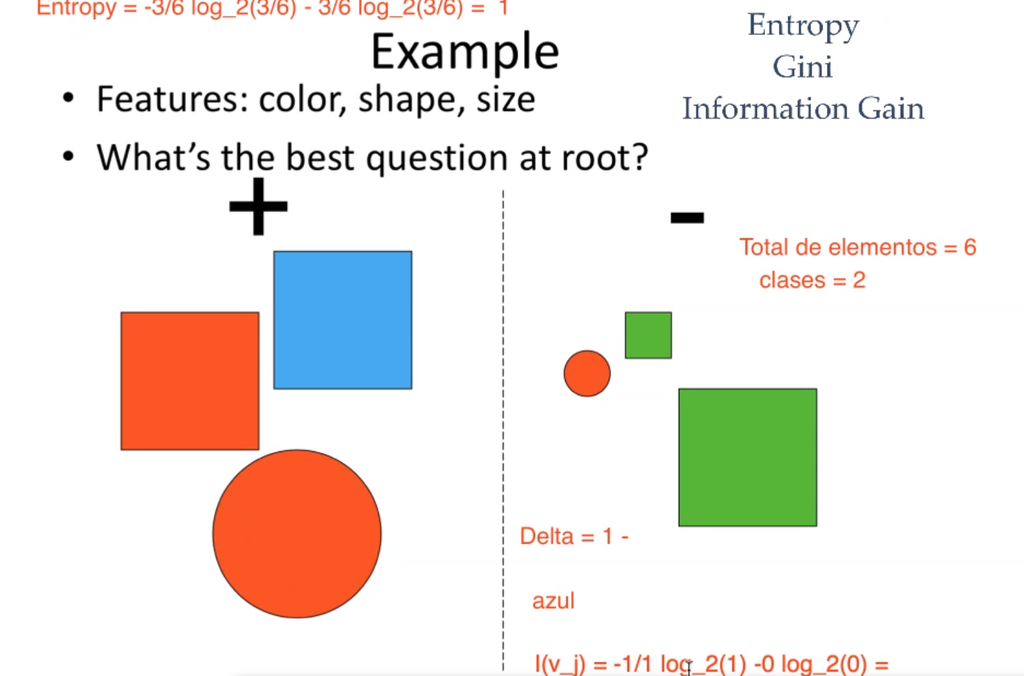

```r
# La entropía
impurity(c(3,3)) %>%
  pull(entropy)
```

```
[1] 1
```

```r
# Total de elementos y clases
t <- 6
clases <- 2 # las clases + ^ -
example2 <- tibble(clase = c(1,1,1,
                             2,2,2),
                   color = c("blue","red","red",
                             "green","red","green"),
                   size = c("big","big","big",
                            "small","small", "big"),
                   shape = c("square", "square", "circle",
                             "square", "circle", "square")
                   )
example2
```

| clase | color | size | shape |
| --- | --- | --- | --- |
| 1 | blue | big | square |
| 1 | red | big | square |
| 1 | red | big | circle |
| 2 | green | small | square |
| 2 | red | small | circle |
| 2 | green | big | square |

```r
# Delta
# azul
example2 %>% filter(color == "blue")
```

| clase | color | size | shape |
| --- | --- | --- | --- |
| 1 | blue | big | square |

Se necesita calcular la entropía y coeficiente de Gini, para posteriormente calcular el **Information Gain**.

La impureza para el nodo raíz:

```r
example2 %>%
  group_by(clase) %>%
  summarise(n = n(), .groups = "drop") %>%
  pull(n) %>%
  impurity()
```

| entropy | gini | classification error |
| --- | --- | --- |
| 1 | 0.5 | 0.5 |

- Azul

$$I(v_j) =- \frac{1}{1} \log_2(1) - 0\log_2(0) = 0$$

- Rojo

```r
-2/3 * log2(2/3)-1/3*log2(1/3)
```

$$I(v_j) =- \frac{2}{3} \log_2(2/3) - \frac{1}{3} \log_2(\frac{1}{3}) = 0.9182958$$

- Verde

$$I(v_j) =- \frac{2}{2} \log_2(1) - 0/2 \log_2(0/2) = 0$$

$$\Delta = 1 - \left(\frac1 6 * 0 + \frac3 6 * 0.9182958 + \frac2 6 * 0 \right) = 0.5408$$

El *information gain* para el **color**, utilizando como función de impureza la entropía.

```r
gain(example2, y_var = "clase", "color", "entropy")
```

```
[1] 0.5408521
```

Comparando la ganancia de información de los atributos:

```r
gain_comparison(example2, y_var = "clase", features = c("color","shape","size"), "entropy")
```

```
    color     shape      size
0.5408521 0.0000000 0.4591479
```

Así, el mejor atributo para el primer nodo sería **color**, puesto que tiene la mayor ganancia de información.

## Ejemplo Titanic

Vemos cuál es el mejor atributo para el primer nodo:

|  | pclass | survived | sex | age | sibsp | parch |
| --- | --- | --- | --- | --- | --- | --- |
| 1 | 1st | survived | female | 29.0000 | 0 | 0 |
| 2 | 1st | survived | male | 0.9167 | 1 | 2 |
| 3 | 1st | died | female | 2.0000 | 1 | 2 |
| 4 | 1st | died | male | 30.0000 | 1 | 2 |
| 5 | 1st | died | female | 25.0000 | 1 | 2 |
| 6 | 1st | survived | male | 48.0000 | 0 | 0 |
| 7 | 1st | survived | female | 63.0000 | 1 | 0 |
| 8 | 1st | died | male | 39.0000 | 0 | 0 |
| 9 | 1st | survived | female | 53.0000 | 2 | 0 |
| 10 | 1st | died | male | 71.0000 | 0 | 0 |

[output cut: 990 more lines]

Resulta ser **sex**.

Vemos sus medidas de impureza:

```r
impurity(ptitanic, "survived")
```

| entropy | gini | classification error |
| --- | --- | --- |
| 0.9594222 | 0.4721383 | 0.381971 |

Vemos sus medidas de impureza para los nodos hijos

```r
ptitanic %>%
  split(.$sex) %>%
  map_df(impurity, y_var = "survived")
```

| entropy | gini | classification error |
| --- | --- | --- |
| 0.8450747 | 0.3965168 | 0.2725322 |
| 0.7035266 | 0.3090189 | 0.1909846 |

```r
ptitanic %>%
  split(.$sex) %>%
  map_df(impurity, y_var = "survived")
```

| entropy | gini | classification error |
| --- | --- | --- |
| 0.8450747 | 0.3965168 | 0.2725322 |
| 0.7035266 | 0.3090189 | 0.1909846 |

## Ejemplo: `weatherPlay`

| outlook | temperature | humidity | windy | play |
| --- | --- | --- | --- | --- |
| sunny | 85 | 85 | false | no |
| sunny | 80 | 90 | true | no |
| overcast | 83 | 86 | false | yes |
| rainy | 70 | 96 | false | yes |
| rainy | 68 | 80 | false | yes |
| rainy | 65 | 70 | true | no |
| overcast | 64 | 65 | true | yes |
| sunny | 72 | 95 | false | no |
| sunny | 69 | 70 | false | yes |
| rainy | 75 | 80 | false | yes |

[output cut: 4 more lines]

```r
gain_comparison(WeatherPlay, y_var = "play",
                features = c("windy","outlook"),impurity_fun = "entropy")
```

```
     windy    outlook
0.04812703 0.24674982
```

```r
weather_tree <- decision_tree(cost_complexity = 0.001) %>%
  set_engine("rpart") %>%
  set_mode("classification") %>%
  translate()
weather_tree
```

```
Decision Tree Model Specification (classification)

Main Arguments:
  cost_complexity = 0.001

Computational engine: rpart

Model fit template:
rpart::rpart(formula = missing_arg(), data = missing_arg(), weights = missing_arg(),
    cp = 0.001)
```

```r
weather_tree_fit <- weather_tree %>%
  fit(play ~ ., data = WeatherPlay)
weather_tree_fit
```

```
parsnip model object

Fit time:  0ms
n= 14

node), split, n, loss, yval, (yprob)
      * denotes terminal node

1) root 14 5 yes (0.6428571 0.3571429) *
```

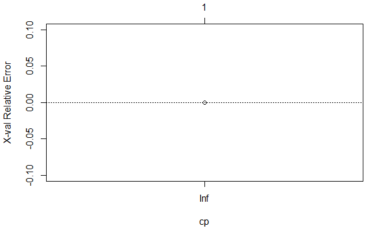

```r
rpart::plotcp(weather_tree_fit$fit)
```

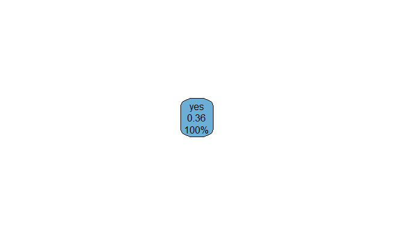

```r
rpart.plot(weather_tree_fit$fit, type = 4,roundint=FALSE)
```